# Cluster Validation using the clValid R Package

Jill R

2019-12-04

## Introduction

Cluster analysis is a powerful, unsupervised data-mining technique that is used to elucidate patterns and/ or the underlying structure of high dimensional datasets, which may not be intuitively obvious. Fundamentally, the key objective of clustering is to split the data into groups so that highly similar observations are tightly clustered from those that are highly distinct in order to minimize the average within cluster distance while maximizing the average distance between clusters [1].

Not surprisingly, cluster analysis is not represented by a single algorithm, but rather, a multitude of algorithms exist[1-3]. Although designed to achieve the same goal (i.e., clustering of the data), these algorithms differ in both the way clusters are identified and defined, resulting in vastly different groupings of the data [1-3]. Unfortunately, there is no single clustering algorithm that consistently outperforms the rest, and therefore, deciding on the most appropriate method for a given dataset can be a fundamentally challenging and overwhelming task [1,3].

When selecting a clustering algorithm, it is common practice for researchers to rely on their prior knowledge and expertise, however, this process can be highly subjective. For example, a researcher may be biased towards selecting an algorithm that validates their own assumptions while disregarding alternative algorithms that may reveal contradicting results [1]. Such an approach is nonetheless counterproductive as it undermines the key purpose of conducting a cluster analysis, which is to discover novel patterns in the data for hypothesis generation and further study [1].

To obtain the most meaningful results, a researcher should always select an algorithm that generates compact, well-separated and biologically relevant clusters [3]. Likewise, it is also important for the researcher to keep in mind that clustering algorithms will attempt to find clusters even when they may not be present in the data. If this caveat is not taken into consideration, non-significant clustering could lead to misinterpretations of the data, potentially impacting downstream analyses and decision-making [1-2]. How can one be certain that the most appropriate clustering algorithm and number of clusters has been selected for a given dataset?

To ensure the results of the cluster analysis are of the highest quality, validation has become an increasingly important step in the cluster analysis workflow [1,3]. Essentially, the role of cluster validation is to evaluate both the appropriateness of the clustering algorithm and the optimal number of clusters for a given dataset [1,3]. When conducting cluster validation, it is recommended to use a variety of validation indices as these metrics can report different optimal clustering solutions for the same dataset, and therefore, using a single index could lead to incorrect assumptions about the validation analysis [4].

As a means for providing researchers with the necessary tools to efficiently validate the results of a cluster analysis, a number of R packages have been developed [5], including fpc [6], factoextra [7], NbClust [8], clv [9], and clValid [3], to name a few. However, unlike most currently available packages, *clValid* offers nine cluster validation measures grouped into three categories (i.e., internal, stability and biological) that can be used to evaluate ten different clustering algorithms (i.e., “hierarchical”, “agnes”, “diana”, “*k*-means”, “pam”, “clara”, “fanny”, “model”, “som”, and “sota”) [3]. As reported by the authors, the most notable strength of the *clValid* package has the ability to perform simultaneous validations of multiple clustering algorithms for a range of clusters and validation measures using a single line of code, which cannot currently be achieved by other programs [3]. As well, the interpretation of the results returned by *clValid* appear to be intuitive and straightforward as the “optimal” clustering algorithm and number of clusters can be returned using the *optimalScores* function based on the overall results of the validation metrics that were assessed [3].

**OBJECTIVE**

The objective of the current study is to determine the optimal clustering method for two high-dimensional datasets (for which the ground truth is known), using the *clValid* R package. Since the datasets contain a maximum of two clusters, the selected clustering algorithms will be assessed using a range of clusters from two to seven. Although a number of clustering algorithms exist within the package, only Hierarchical, *k*-means and PAM (i.e., *k*-medoids) will be investigated as these methods were explicitly discussed in class, and therefore, it is assumed that the intended audience will have a baseline knowledge of their inner workings. As a refresher, a brief overview of each methods as previously described in Holmes and Huber [2] is included below.

- *Partition-based*
  - Subdivide observations into k groups based on similarity to cluster centroids
  - The number of clusters (k) must be pre-specified by the researcher
    - Observations are placed in the cluster containing the cluster center it is closest to
    - Cluster centers are updated and the process is repeated until the clusters stabilize
  - Example algorithms include *k*-means and *k*-medoids (i.e., Partitioning Around Medoids; PAM)
    - Centroid is not represented by a single point in *k*-means, but rather, a collection of points (i.e., average distance of all points in a single cluster)
    - Centroid, or more appropriately termed, Medoid is the most central point in the cluster for *k*-medoids (i.e. PAM)
- *Hierarchical*
  - Tree-based (i.e., dendrogram) visualization of the observations
  - Does not require prior knowledge of the number of clusters (k)
  - Bottom-up approach
    - Agglomerative
      - Most common hierarchical clustering method
      - Used to find small clusters
      - Single observation clusters are iteratively merged based on similarity until all observations are contained in a single, large cluster.
  - Top-down approach
    - Divisive
      - All observations begin in a single large cluster and are iteratively separated based on dissimilarity until all observations are in their own cluster.
      - Not commonly used

## Important Note

The default distance metric for the available clustering algorithms and validation measures in the *clValid* package is set to “euclidean”. Additionally, the agglomerative method for hierarchical clustering is defaulted to “average linkage”. However, these parameters can be modified using the “metric” and method" switch, respectively, in the *clValid* function [3]. For the purposes of this study, all default parameters will be used unless otherwise noted.

## Datasets

The datasets that have been selected for analysis include two genomic datasets from the PulseNet Canada, which is the national molecular subtyping network for foodborne disease surveillance in Canada [9]. More specifically, the datasets contain allele data derived from whole-genome multilous sequence typing (wgMLST), which is a gene-by-gene approach that detects variation within a set of microbial genomes using a predefined set of pan-genomic loci (i.e., genes) [10].

**Outbreak 1**

The Outbreak 1 dataset contains whole-genome multilocus sequencing type (wgMLST) allele data for 74 *Listeria monocytogenes* isolates associated with two outbreaks, one of which was associated with ready to eat (RTE) meat products (n = 62), and the other, was linked to the consumption of contaminated leafy greens (n = 12).

**Sporadic**

Based on the fact that clustering algorithms are designed to find clusters, even if they do not actually exist within the data, a sporadic dataset (i.e., contains ONLY unrelated isolates) was selected to investigate the cluster validation results returned by the *clValid* package. This dataset contains wgMLST allele data for 26 *Listeria monocytogenes* isolates that were referred to the PNC network within a similar time frame but where considered to be epidemiologically unrelated (i.e., similar exposures were not identified).

## Data Preparation

To successfully run the *clValid* R package, the data must be formatted as a numeric matrix, data frame or an *ExpressionSet* object, and the columns MUST ONLY contain numeric data (i.e., NA’s must be replaced and categorical variables must be removed). Most importantly, the *clValid* function operates under the assumption that the rows in the dataset contain the “observations” that are intended to be clustered [3], and thus, special care must be exercised when formatting the data for analyses.

**Load the Datasets**

*Outbreak 1*

```r
#Load data and set row.name to Isolate and replace ? with NA's
LmOB2_data = read.csv(here("LmOutbreakData.csv"), row.names = "Isolate", na.strings = "?")

#Remove categorial variables
LmOB2_subdata = subset(LmOB2_data, select = -c(Group))

#Check data for NA's
table(is.na(LmOB2_subdata)) #20896 NA's in the dataset; these actually represent NO allele call for a particular locus
```

```
##
##  FALSE   TRUE
## 222120  20896
```

```r
#Replace NA's with 99 (i.e., use an arbitrary # that is not already represented in the dataset)
LmOB2_clean = replace(LmOB2_subdata, is.na(LmOB2_subdata), 99L) # replacing with zero proved to cause internal issues with the clustering algorithms so 99 is being used; less problematic
#L is used to change the objects from dbl integer to interger, which also proved to be an issue for downstream analyses

# Identify which columns (i.e., loci) have zero variance
which(apply(LmOB2_clean, 2, var)==0)
```

```
## LMO00125 LMO00277 LMO00417 LMO00474 LMO00708 LMO01547 LMO01576 LMO01681
##       27       94      222      279      489     1299     1328     1433
## LMO02028 LMO02758 LMO02819 LMO02820 LMO02825 LMO02827 LMO02834 LMO02835
##     1777     2457     2517     2518     2523     2525     2532     2533
## LMO02839 LMO03064 LMO03161 LMO03384 LMO03891 LMO03908 LMO04070 LMO04503
##     2537     2760     2840     2899     3027     3037     3199     3243
## LMO04531
##     3256
```

```r
#Example of Locus LMO00125, which has zero variance
summary(LmOB2_clean$LMO00125)
```

```
##    Min. 1st Qu.  Median    Mean 3rd Qu.    Max.
##       1       1       1       1       1       1
```

```r
#Remove columns with 0 variance as it is problematic for downstreamn analyses
LmOB2 = LmOB2_clean[ ,apply(LmOB2_clean, 2, var) !=0]

#Check to see that columns have been removed
dim(LmOB2_clean) #contains columns with zero variance
```

```
## [1]   74 3284
```

```r
dim(LmOB2) # 25 columns with zero variance have been removed
```

```
## [1]   74 3259
```

**Sporadic**

```r
#Load data and set row.name to Isolate and replace ? with NA's
LmSP_data = read.csv("./LmSporadic.csv", row.names = "Isolate", na.strings = "?")

#Remove categorial variables
LmSP_subdata = subset(LmSP_data, select = -c(Group))

#Check data for NA's
table(is.na(LmSP_subdata)) #29509 NA's in the dataset; these actually represent NO allele call for a particular locus
```

```
##
## FALSE  TRUE
## 73841 29509
```

```r
#Replace NA's with 99
LmSP_clean = replace(LmSP_subdata, is.na(LmSP_subdata), 99L) # replacing with zero proved to cause internal issues with the clustering algorithms so 99 is being used; less problematic
#L is used to change the objects from dbl integer to interger, which also proved to be an issue for downstream analyses

# Identify which columns (i.e., loci) have zero variance
which(apply(LmSP_clean, 2, var)==0)
```

```
## LMO00132 LMO00474 LMO01547 LMO01576 LMO01681 LMO02028 LMO02820 LMO02825
##       63      368     1408     1437     1542     1889     2668     2673
## LMO02835 LMO02839
##     2683     2687
```

```r
#Example of Locus LMO00048, which has zero variance
summary(LmSP_clean$LMO00132)
```

```
##    Min. 1st Qu.  Median    Mean 3rd Qu.    Max.
##       1       1       1       1       1       1
```

```r
#Remove columns with 0 variance as it is problematic for eclust in the factoextra R package
LmSP = LmSP_clean[ ,apply(LmSP_clean, 2, var) !=0]

#Check to see that columns have been removed
dim(LmSP_clean) #contains columns with zero variance
```

```
## [1]   26 3975
```

```r
dim(LmSP) # 10 columns with zero variance have been removed
```

```
## [1]   26 3965
```

The authors of *clValid* recommend to run all validation measures simultaneously for each of the cluster algorithms over a range of cluster numbers as it is reported to be more computationally efficient [3], however for the current study, the validation measures will be run separately. Following a preliminary analysis of the data, it was discovered that some metrics are quite computationally demanding (i.e., stability), and therefore, require additional resources beyond the capabilities of RStudio.

## Internal Validity

The purpose of internal validation measures is to assess the appropriateness of the clustering algorithm based on the intrinsic properties of the dataset, and therefore, these metrics do not take into account external sources of information [1, 3, 10]. More specifically, these measures are used to evaluate whether the selected clustering algorithm captures the natural structure of the data.

Three internal validation metrics have been implemented in the *clValid* package, and include “connectedness”, “compactness”, and “separation” [3]. A brief explanation of each metric is included below.

*Connectivity*

Connectivity, or more commonly, connectedness, is used to measure the degree to which observations are placed in the same cluster as their “*k*-nearest” neighbours (for a given algorithm) [3, 10].

For a particular clustering algorithm, $C = {C_{1,...,}C_{K}}$, the connectivity can be defined as follows:

$$Conn(C) = \sum_{i=1}^N\sum_{j=1}^Lx_{i,nn_{i(j)}}$$

- Where,
  - *L* = number of neighbours that contribute to the connectivity
  - *N* = number of observations placed into *k* clusters
  - $nn_{i(j)}$ = is the *j*th nearest neighbour to observation *i*
  - $x_{i,nn_{i(j)}}$ = zero if *i* and $nn_{i(j)}$ are in the same cluster, and 1/*j* if they are not in the same cluster

The connectivity validation measure returns a value between zero and infinity, where lower values (i.e., closer to zero) reflect optimal connectivity [3].

*Compactness and Separation*

Compactness is used to assess how close observations are within the same cluster (i.e., intra-cluster variance), while separation quantifies the distance between clusters. The neighbSize, which indicates the number of observations to consider “neighbours” when calculating the connectivity is set to a default of 10 [3]. This default was used unless otherwise stated.

Given the opposing nature of these metrics (i.e., an increase in the compactness of clusters will result in a subsequent decrease in the separation between clusters), these measures are typically combined into a single score. Two commonly used methods that assess both the compactness and separation of clusters are the Silhouette Width [3, 4, 11, 12] and the Dunn Index [3, 4, 11, 13], which are described in greater detail below.

*Silhouette Width*

The Silhouette Width is used to evaluate how well observations are clustered based on the average distance between clusters (i.e., how close is an observation in one cluster to an observation in a neighbouring cluster?) [3, 4, 12].

The Silhouette Width is defined as follows and is computed according to the following steps:

$$S(i) = \frac{b_i - a_i}{max(b_i, a_i)}$$

1. Calculate the average dissimilarity, $a_i$, for each observation, *i*, and all other observations in the same cluster.
2. Calculate the average dissimilarity, $d(i, C)$ of $i$ to all observations in other clusters $C$. The smallest value of $d(i, C)$ is defined as $b_i = min_c d(i, C)$, where $b_i$ is the average distance between $i$ and the observations in the nearest cluster to which it does not belong.

The $S_i$ values are reported in the range of -1 to 1 where observations are considered to be well clustered if the $S_i$ value is large (i.e., close to 1). In contrast, an $S_i$ value close to zero indicates the observation likely lies somewhere between two clusters, while a negative $S_i$ value suggests the observation is most likely in the wrong cluster [11].

*Dunn Index*

Provides a ratio of the smallest distance between two observations that are not in the same cluster to the largest distance between observations in the same cluster. The values reported for the Dunn Index are between zero and infinity with a large Dunn Index indicating the clusters are compact and well-separated [3, 11, 13].

The Dunn Index is defined as follows and is computed according to the following steps:

$$D = \frac{min.separation}{max.diameter}$$

1. Compute the distance between each observation in a cluster and the observations in other clusters to determine the minimum pairwise inter-cluster distance, which represents the $min.separation$.
2. Compute the distance between observations in the same cluster to determine the maximal intra-cluster distance, which represents the $max.diameter$.

**Internal Validity Assessment**

*Outbreak 1*

```r
#Internal Validity Check for 2 to 7 clusters for 3 clustering methods
intcheck_LmOB2 = clValid(LmOB2, nClust = 2:7, clMethods = c("hierarchical", "kmeans", "pam"), validation = "internal")

#View summary results and optimal scores
summary(intcheck_LmOB2)
```

```
##
## Clustering Methods:
##  hierarchical kmeans pam
##
## Cluster sizes:
##  2 3 4 5 6 7
##
## Validation Measures:
##                                  2       3       4       5       6       7
##
## hierarchical Connectivity   0.0000  2.9290  2.9290  5.8579  8.7869 11.7159
##              Dunn           1.1787  1.1159  0.7952  0.7941  0.7995  0.7618
##              Silhouette     0.6934  0.5859  0.5285  0.4934  0.4630  0.4570
## kmeans       Connectivity   0.0000  2.9290  2.9290  8.7869 20.3361 20.3361
##              Dunn           1.1787  1.1159  0.7952  0.6475  0.6207  0.6207
##              Silhouette     0.6934  0.5859  0.5285  0.4931  0.4431  0.4403
## pam          Connectivity   0.0000  0.0000  4.3825  7.3115 10.2405 13.1694
##              Dunn           1.1787  0.4739  0.3400  0.5603  0.5603  0.5835
##              Silhouette     0.6934  0.5198  0.4699  0.4838  0.4487  0.4234
##
## Optimal Scores:
##
##              Score  Method       Clusters
## Connectivity 0.0000 hierarchical 2
## Dunn         1.1787 hierarchical 2
## Silhouette   0.6934 hierarchical 2
```

```r
optimalScores(intcheck_LmOB2)
```

```
##                  Score       Method Clusters
## Connectivity 0.0000000 hierarchical        2
## Dunn         1.1786937 hierarchical        2
## Silhouette   0.6933805 hierarchical        2
```

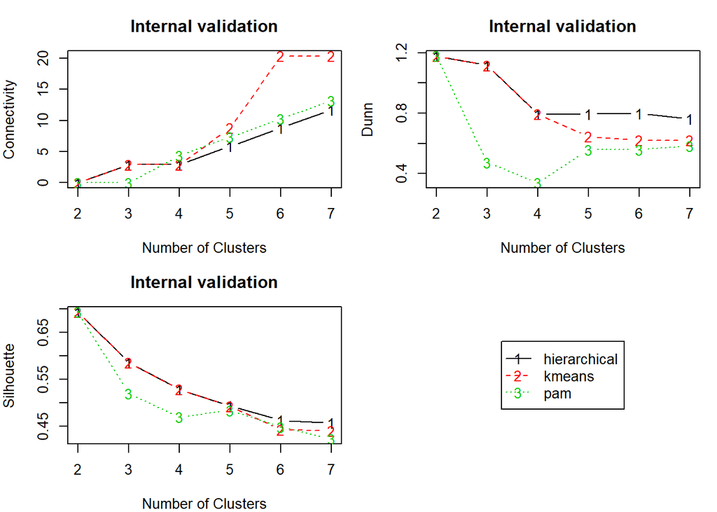

```r
#Plot the Results
par(mfrow = c(2, 2), mar = c(4, 4, 3, 1))
plot(intcheck_LmOB2, legend = FALSE)
plot(nClusters(intcheck_LmOB2), measures(intcheck_LmOB2, "Dunn")[, , 1], type = "n",
     axes = F, xlab = "", ylab = "")
legend("center", clusterMethods(intcheck_LmOB2), col = 1:3, lty = 1:3, pch = paste(1:3))
```

Based on the optimal scores for the internal validation results for the Outbreak 1 dataset, it appears that hierarchical clustering with k=2 clusters is a more suitable algorithm than *k*-means or PAM. The connectivity is minimized, whereas the Dunn Index and Silhouette Width are maximized. This suggests that the hierarchical clustering method with k=2 clusters generates clusters that are compact, well-separated and demonstrate optimal connectivity.

*Sporadic*

```r
#Internal Validity Check for 2 to 7 clusters for 3 clustering methods
intcheck_LmSP = clValid(LmSP, nClust = 2:7, clMethods = c("hierarchical", "kmeans", "pam"), validation = "internal")

#View summary results and optimal scores
summary(intcheck_LmSP)
```

```
##
## Clustering Methods:
##  hierarchical kmeans pam
##
## Cluster sizes:
##  2 3 4 5 6 7
##
## Validation Measures:
##                                  2       3       4       5       6       7
##
## hierarchical Connectivity   4.1258  8.7159  9.7159 12.6448 15.7849 18.7139
##              Dunn           0.7905  0.7559  0.7559  0.8889  0.7272  0.7158
##              Silhouette     0.5159  0.3796  0.3191  0.2905  0.1703  0.1233
## kmeans       Connectivity   7.1147 13.5238 18.4290 19.8901 29.1012 37.4016
##              Dunn           0.6882  0.4590  0.5176  0.5488  0.6060  0.6423
##              Silhouette     0.4475  0.3190  0.2257  0.2087  0.1232  0.1236
## pam          Connectivity   5.6857  6.7869 13.5369 16.4659 19.3948 23.4627
##              Dunn           0.8376  0.8376  0.4806  0.5250  0.6115  0.6344
##              Silhouette     0.4850  0.4086  0.1242  0.1353  0.1463  0.1573
##
## Optimal Scores:
##
##              Score  Method       Clusters
## Connectivity 4.1258 hierarchical 2
## Dunn         0.8889 hierarchical 5
## Silhouette   0.5159 hierarchical 2
```

```r
optimalScores(intcheck_LmSP)
```

```
##                  Score       Method Clusters
## Connectivity 4.1257937 hierarchical        2
## Dunn         0.8888771 hierarchical        5
## Silhouette   0.5159272 hierarchical        2
```

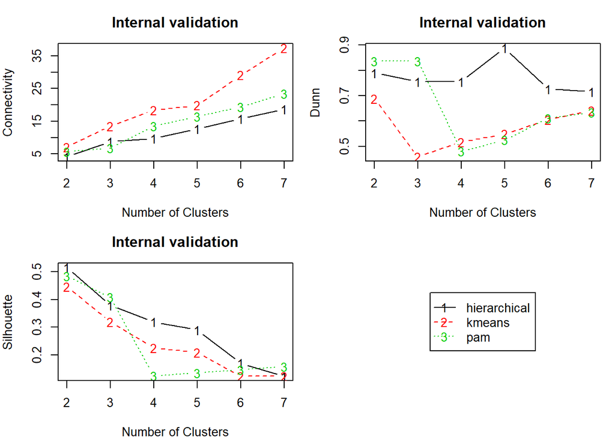

```r
#Plot the Results
par(mfrow = c(2, 2), mar = c(4, 4, 3, 1))
plot(intcheck_LmSP, legend = FALSE)
plot(nClusters(intcheck_LmSP), measures(intcheck_LmSP, "Dunn")[, , 1], type = "n",
     axes = F, xlab = "", ylab = "")
legend("center", clusterMethods(intcheck_LmSP), col = 1:3, lty = 1:3, pch = paste(1:3))
```

According to the results for the Sporadic Dataset, hierarchical also appears to be the most suitable clustering method, however, there is not an obvious consensus on the optimal number of clusters. This result is to be expected as the dataset does not contain any clusters. Although the connectivity measure suggests an optimal number of two clusters for the hierarchical clustering algorithm, the reported value is high (i.e., >4). Since the Dunn Index might be the most optimal score reported (0.8888), a cluster size of k=5 may be the most suitable. To determine what would happen if the number of clusters was modified, k was increased to k=25 for the Sporadic dataset. This resulted in an increase in the Dunn Index, while the other metrics remained relatively constant. In contrast, as the number of clusters (k) was increased for Outbreak 1, all values remained relatively constant as the number of optimal clusters was likely already detected.